# Outside Item Memory

> This notebook focuses on item memory outside the rooms.

# 1 Overview of the data

The rooms were separated into *Familiar* and *Novel* groups. Participants explored the *Familiar* group at the beginning of the experiment. In the encoding task, they visisted both *Familiar* and *Novel* groups. Their item memory (i.e., in which room they saw the item) was tested in the memory test the next day of the encoding task. **Novelty benefits** on the item memory are examined by comparing the memory performance between the *Familiar* and *Novel* groups.

Participants were also asked to rate how curious they felt about the room. The higher the rating is means they felt more curious about the room. Item memory as a function of curiosity rating was also examined for **curiosity benefits**.

Questionnaires on personal traits regarding curiosity were also administered to participants before the encoding task (i.e., PC and EC). Scores on these questionnaires might be able to predict the item memory or its relationship with curiosity rating.

In the encoding task, there were 6 objects in each room. It is possbile that the item memory for the object to some extent depends on the order in which the object was seen. For example, it may be easier to remember where the first and last objects were seen as compared to those in the middle.

# 2 Visual inspection of the data

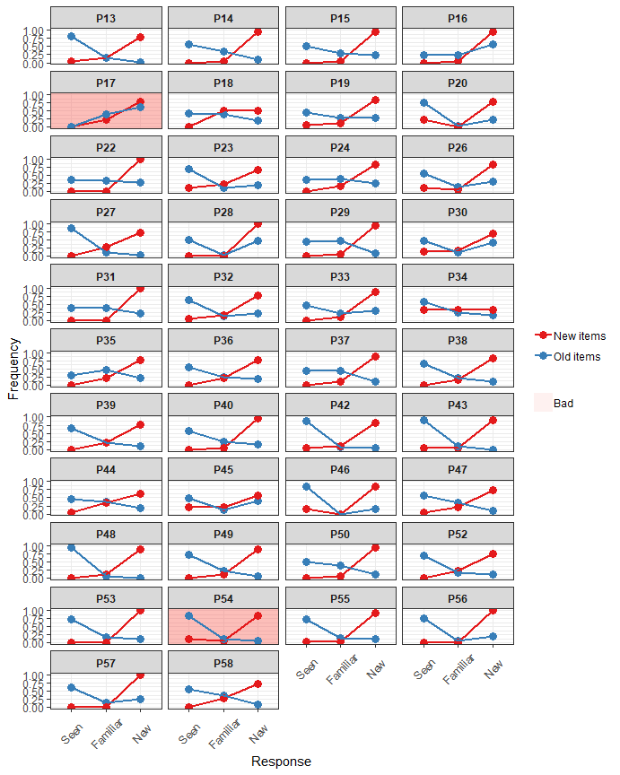

# 3 Novelty Benefits

We hypothesised that the memory for the items outside the rooms should be better for the *novel* rooms than for the *familiar* rooms.

## 3.1 Compare mean accuracy between *novel* and *familiar* rooms

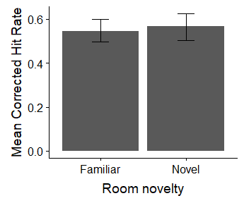

```
    Paired t-test

data:  MeanCorrSeenHit by Group
t = -0.7, df = 40, p-value = 0.5
alternative hypothesis: true difference in means is not equal to 0
95 percent confidence interval:
 -0.0753  0.0355
sample estimates:
mean of the differences
                -0.0199
```

## 3.2 Item memory as a function of item order

### 3.2.1 Visualise the data

#### 3.2.1.1 Nonlinear

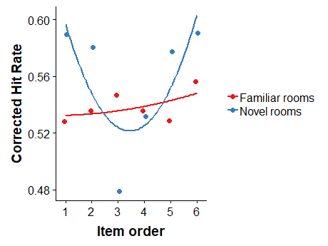

#### 3.2.1.2 Linear

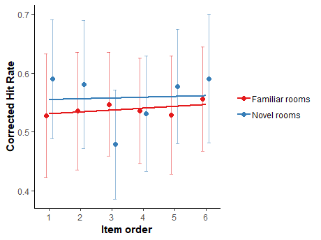

### 3.2.2 Testing novelty effects by fitting mixed models

Build models with item memory accuracy as $y$ and then examine effects of novelty by comparing the models.

|  | Model | df | AIC | BIC | logLik | Test | L.Ratio | p-value |
| --- | --- | --- | --- | --- | --- | --- | --- | --- |
| baseline.item | 1 | 4 | 153 | 170 | -72.4 |  |  |  |
| order.model.linear.1 | 2 | 5 | 155 | 176 | -72.4 | 1 vs 2 | 0.10 | 0.748 |
| order.model.linear.2 | 3 | 9 | 157 | 195 | -69.7 | 2 vs 3 | 5.33 | 0.255 |
| novelty.model.1 | 4 | 10 | 159 | 201 | -69.4 | 3 vs 4 | 0.55 | 0.460 |
| novelty.model.2 | 5 | 11 | 161 | 207 | -69.4 | 4 vs 5 | 0.02 | 0.889 |

#### 3.2.2.1 Parameter estimation for the complete model

### 3.2.3 Collapse the order and novelty group

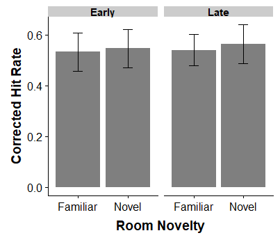

#### 3.2.3.1 Stats on it

##### 3.2.3.1.1 Using `lme`

|  | Model | df | AIC | BIC | logLik | Test | L.Ratio | p-value |
| --- | --- | --- | --- | --- | --- | --- | --- | --- |
| baseline | 1 | 5 | -59.3 | -43.9 | 34.6 |  |  |  |
| NoveltyModel | 2 | 6 | -57.7 | -39.3 | 34.9 | 1 vs 2 | 0.454 | 0.500 |
| OrderModel | 3 | 7 | -55.9 | -34.4 | 35.0 | 2 vs 3 | 0.225 | 0.635 |
| repeatedModel | 4 | 8 | -54.0 | -29.4 | 35.0 | 3 vs 4 | 0.036 | 0.849 |

```
Linear mixed-effects model fit by maximum likelihood
 Data: Encoding.Recall.Old.Order.Novelty[!SubjectNo %in% bad.ps.less.strict]
```

|  | AIC | BIC | logLik |
| --- | --- | --- | --- |
|  | -54 | -29.4 | 35 |

```
Random effects:
 Formula: ~1 | SubjectNo
        (Intercept)
StdDev:       0.153

 Formula: ~1 | Group %in% SubjectNo
        (Intercept)
StdDev:       0.053

 Formula: ~1 | ItemOrderType %in% Group %in% SubjectNo
        (Intercept) Residual
StdDev:       0.146   0.0501

Fixed effects: CorrSeenHit ~ Group + ItemOrderType + Group:ItemOrderType
```

|  | Value | Std.Error | DF | t-value | p-value |
| --- | --- | --- | --- | --- | --- |
| (Intercept) | 0.533 | 0.0358 | 78 | 14.90 | 0.000 |
| GroupNovel | 0.014 | 0.0369 | 39 | 0.37 | 0.713 |
| ItemOrderTypeLate | 0.007 | 0.0349 | 78 | 0.20 | 0.843 |
| GroupNovel:ItemOrderTypeLate | 0.009 | 0.0494 | 78 | 0.19 | 0.851 |

```
 Correlation:
                             (Intr) GrpNvl ItmOTL
GroupNovel                   -0.516
ItemOrderTypeLate            -0.488  0.473
GroupNovel:ItemOrderTypeLate  0.345 -0.669 -0.707

Standardized Within-Group Residuals:
     Min       Q1      Med       Q3      Max
-0.67556 -0.20818  0.00266  0.22260  0.70770

Number of Observations: 160
Number of Groups:
                              SubjectNo                    Group %in% SubjectNo
                                     40                                      80
ItemOrderType %in% Group %in% SubjectNo
                                    160
```

##### 3.2.3.1.2 Using `ezANOVA`

```r
repeatedModel<-ezANOVA(data = Encoding.Recall.Old.Order.Novelty[!SubjectNo %in% bad.ps.less.strict], dv = .(CorrSeenHit), wid = .(SubjectNo),  within = .(Group, ItemOrderType), type = 3, detailed = TRUE)
options(digits = 3)
repeatedModel
```

[output not shown]

##### 3.2.3.1.3 Simple effects for the “early” group

##### 3.2.3.1.4 Simple effects for the “late” group

# 4 Curiosity Benefits

We hypothesed that the higher the curiosity rating was, the better the item memory should be.